# 预测三七互娱股票走势的时序分析

陈炜锻

2021-01-08 11:55:32

## 目录

*处理数据

*平稳序列

*拟合模型

*评估模型

*模型预测

## ARIMA模型要点

AR是指差分序列的滞后数，MA是指误差的滞后数，I是使时间序列平稳的差分次数数

ARIMA模型要求数据是平稳的，这意味着数据的均值和方差并不会随着时间的推移而变化，同时ARIMA模型是用自身数据来预测未来，故存在一些局限性

## 处理数据

加载需要用到的包

```r
library(lubridate)
library(tseries)
library(forecast)
```

读取从网上下载的股票数据

```r
stock <- read.csv("E:/data/price.csv")
```

查看数据集的列名

```r
colnames(stock)
```

```
##  [1] "X"                "secID"            "ticker"
##  [4] "secShortName"     "exchangeCD"       "tradeDate"
##  [7] "preClosePrice"    "actPreClosePrice" "openPrice"
## [10] "highestPrice"     "lowestPrice"      "closePrice"
## [13] "turnoverVol"      "turnoverValue"    "dealAmount"
## [16] "turnoverRate"     "accumAdjFactor"   "negMarketValue"
## [19] "marketValue"      "chgPct"           "PE"
## [22] "PE1"              "PB"               "isOpen"
## [25] "vwap"
```

由于时间序列的自相关性，ARIMA模型只适用于预测与自身前期相关的现象,故数据应为单变量。对此，我们只需股票数据中两列：日期和当日收盘价

```r
stock <- stock[,c("tradeDate","closePrice")]
stock$tradeDate <- as_date(stock$tradeDate)
```

将数据集划分为训练集和测试集，训练集用于训练，测试集用于与预测结果做对比

```r
train <- stock[1:(nrow(stock)*0.9),]
test <- stock[(nrow(stock)*0.9):nrow(stock),]
```

转化为时间序列格式ts

```r
train.ts<- ts(train$closePrice)#将数据集转化为时间序列格式ts
test.ts <- ts(test$closePrice,start = nrow(stock)*0.9)
```

作图观察数据分布

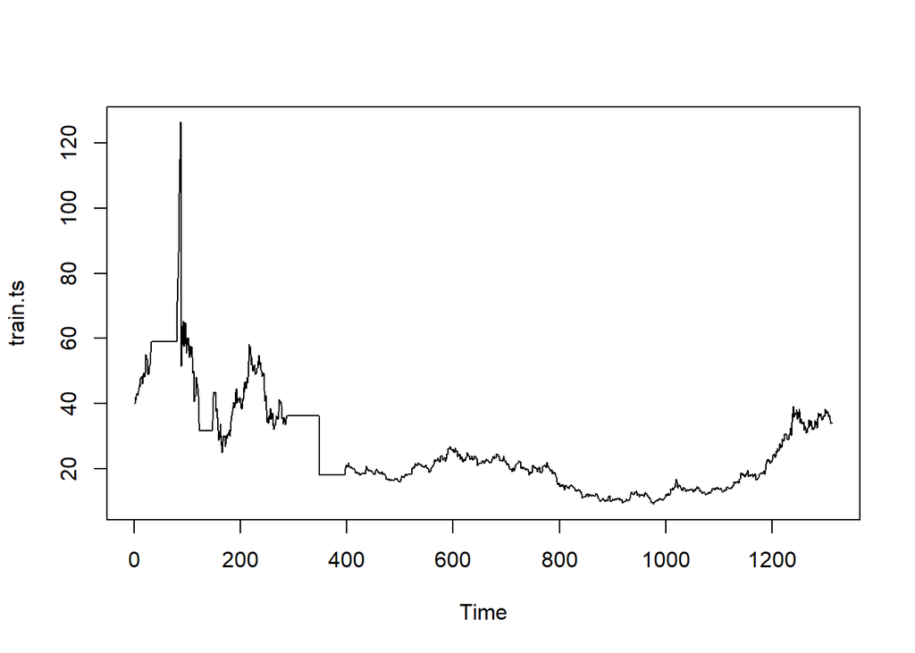

```r
plot(train.ts)
```

从图可以看出，数据总体整体呈现下降的趋势，存在突然升高的异常值

## 平稳序列

首先对股票数据进行ADF单方根检验,以检测数据是否平稳

```r
adf.test(train.ts)
```

```
##
##  Augmented Dickey-Fuller Test
##
## data:  train.ts
## Dickey-Fuller = -1.9428, Lag order = 10, p-value = 0.6025
## alternative hypothesis: stationary
```

从结果中可以看出，p值显著性大于0.05，说明数据分布不平稳，是不平稳序列，所以需要对此进行一阶差分处理，故差分次数d=1

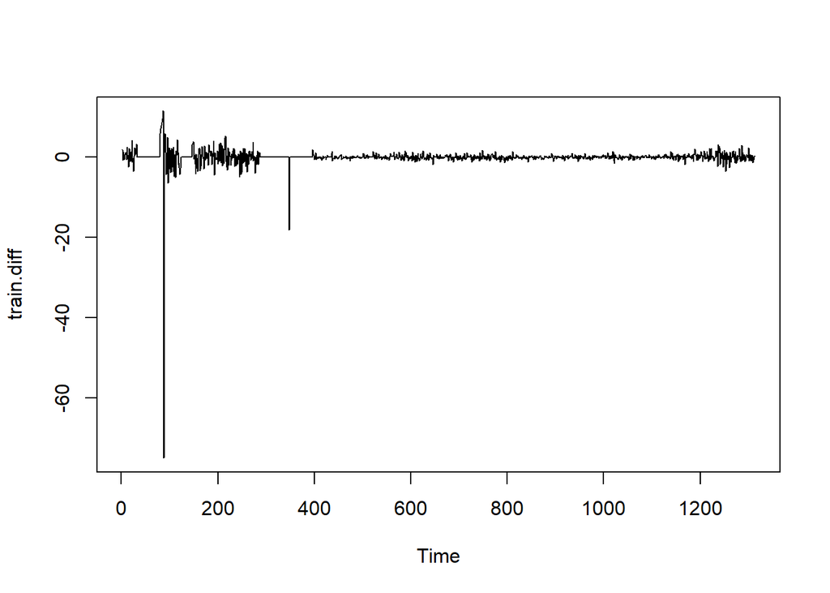

```r
train.diff <- diff(train.ts,lag = 1)
test.diff <- diff(test.ts,lag=1)
plot(train.diff)
```

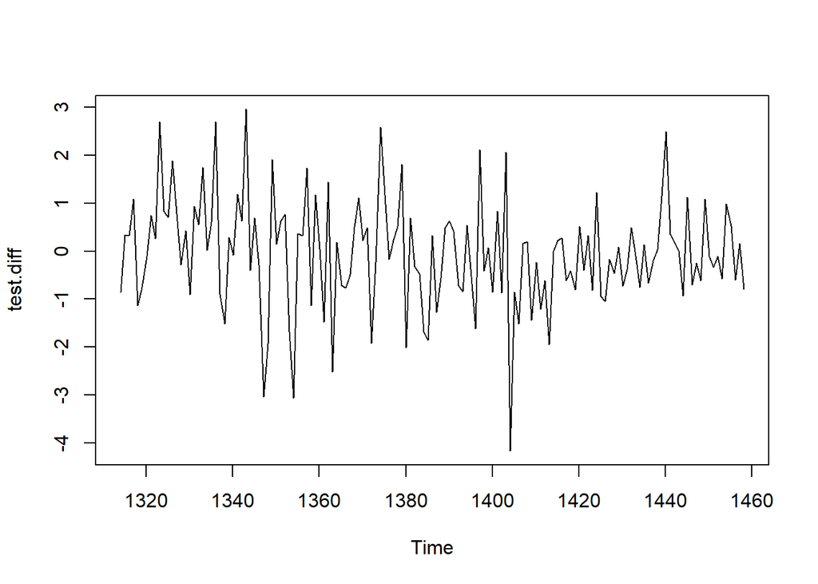

```r
plot(test.diff)
```

上图显示，经过差分处理的序列已趋于平稳，我们再对数据做多一次ADF检测

```r
adf.test(train.diff)
```

```
##
##  Augmented Dickey-Fuller Test
##
## data:  train.diff
## Dickey-Fuller = -13.486, Lag order = 10, p-value = 0.01
## alternative hypothesis: stationary
```

得出的p值实际上比显示的更小，说明现在的序列已是平稳序列，可以进行分析的下一步

## 拟合模型

forecast包中有个auto.arima函数，其算法是使用逐步搜索遍历模型空间，以选择具有最小AICc的最佳模型，简而言之，就是替你选好性能最好的p，d，q值组合来拟合模型，是个简便的工具

```r
auto.arima(train.diff,
           seasonal.test = "ch",
           parallel=TRUE,
           num.cores=8,
           stepwise=FALSE,
           approximation=FALSE)
```

```
## Series: train.diff
## ARIMA(1,0,1) with zero mean
##
## Coefficients:
##          ar1      ma1
##       0.7430  -0.8640
## s.e.  0.0472   0.0348
##
## sigma^2 estimated as 5.857:  log likelihood=-3020.25
## AIC=6046.5   AICc=6046.52   BIC=6062.04
```

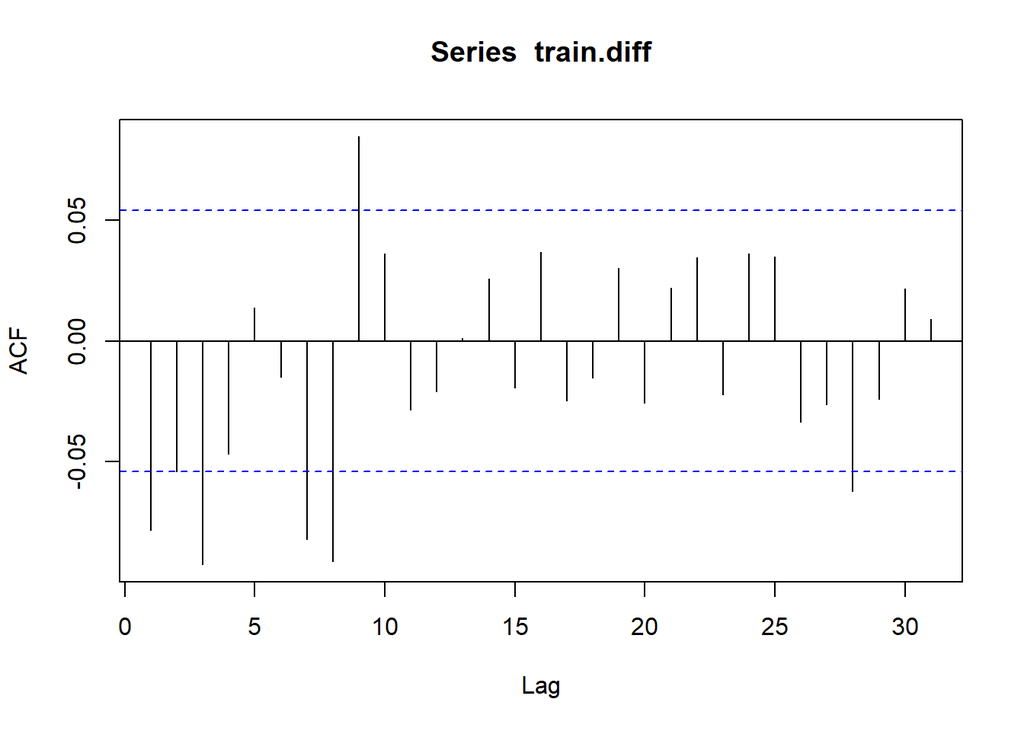

```r
Acf(train.diff)
```

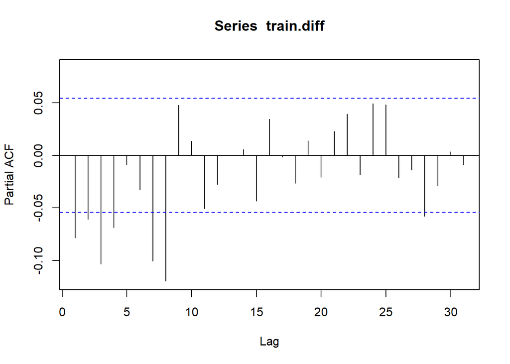

```r
Pacf(train.diff)
```

ACF是生成自相关图的函数，用以确定q阶数，PACF是生成偏自相关图的函数，用以确定p阶数，从两张图中可见p=2，q=2，我们将此用于拟合模型

```r
model <- stats::arima(train.diff,order = c(2,1,2),method = "ML")#要注明stats包，不然预测时会报错
```

其中，order的三个参数分别对应p，d，q，选择最大似然的拟合方法。拟合好模型之后，我们对模型的性能进行初步检验

```r
AIC(model)
```

```
## [1] 6054.774
```

```r
BIC(model)
```

```
## [1] 6080.666
```

## 评估模型

```r
Box.test(model$residuals,type="Box-Pierce")
```

```
##
##  Box-Pierce test
##
## data:  model$residuals
## X-squared = 0.0012635, df = 1, p-value = 0.9716
```

对残差序列进行白噪音检测，得出的p值大于0.05，说明模型显著性成立

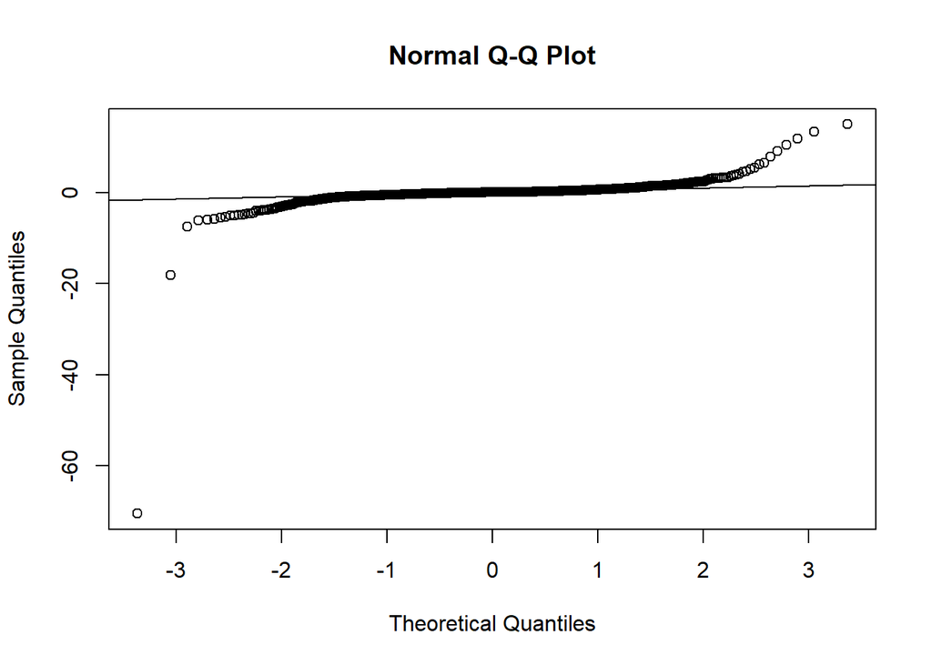

```r
qqnorm(model$residuals)
qqline(model$residuals)
```

## 模型预测

使用置信度99.5%的模型预测数量等于测试集的未来值

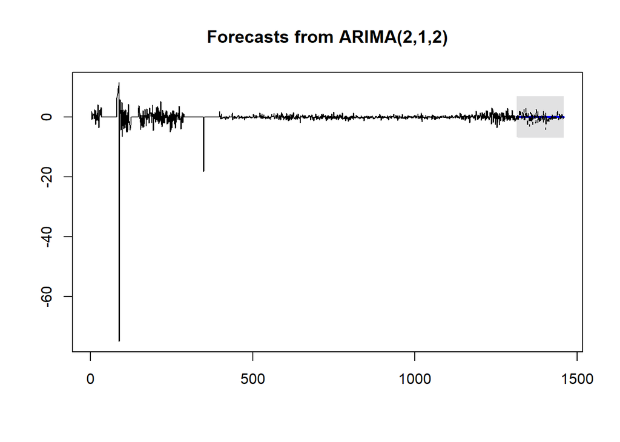

```r
stock.forecast<-forecast(model,h = nrow(test),level = c(99.5))
plot(stock.forecast)#蓝色线条为预测值，阴影区域即是置信度水平
lines(test.diff,lty = 2)#实际值用虚线标出，与预测值做对比
```